# Some examples of manipulating and visualizing time series data using pandas and matplotlib

```python
import pandas as pd
import matplotlib.pyplot as plt
from datetime import datetime, timedelta
%matplotlib inline
```

Read some sample data from a CSV file. The same data which contains timestamps and a temperature values taken every 10 minutes over an extended period. This is what it looks like

```python
df = pd.read_csv("data.csv", parse_dates=["Timestamp"], index_col='Timestamp')
df.sort_index(inplace=True)
df.head(20)
```

| Timestamp | Temperature |
| --- | --- |
| 2016-11-11 00:10:00 | 29 |
| 2016-11-11 00:20:00 | 5 |
| 2016-11-11 00:30:00 | 44 |
| 2016-11-11 00:40:00 | 15 |
| 2016-11-11 00:50:00 | 16 |
| 2016-11-11 01:00:00 | 10 |
| 2016-11-11 01:10:00 | 12 |
| 2016-11-11 01:20:00 | 5 |
| 2016-11-11 01:30:00 | 27 |
| 2016-11-11 01:40:00 | 29 |
| 2016-11-11 01:50:00 | 1 |
| 2016-11-11 02:00:00 | 11 |
| 2016-11-11 02:10:00 | 37 |
| 2016-11-11 02:20:00 | 21 |
| 2016-11-11 02:30:00 | 1 |
| 2016-11-11 02:40:00 | 14 |
| 2016-11-11 02:50:00 | 24 |
| 2016-11-11 03:00:00 | 8 |
| 2016-11-11 03:10:00 | 9 |
| 2016-11-11 03:20:00 | 31 |

For the purposes of visualization you need to to summarize the data in some way that makes the graph generated useful. Pandas provides many useful statistical techniques to do this. I find using a rolling window useful.

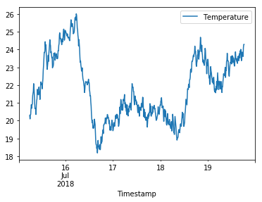

```python
df[datetime(2018,7,15) : datetime(2018,7,20)].rolling(window=72, center=True).mean().plot()

# Make the date range open ended with something like this, adding in the rolling window as above:
# df[datetime(2018,7,20) :].plot()
plt.show()
```

Here is a plot of the temperature over the last hour which can usefully done without any windowing. Again pandas tries to do something sensible with the axis labels.

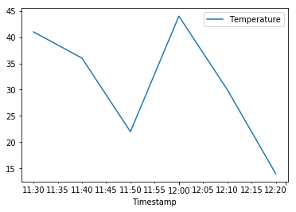

```python
# Temperatures over the last hour
df1 = df[datetime.now() - timedelta(seconds=(60* 60)): datetime.now()]
df1.plot()
plt.show()
```